# Recommendation System

#### Assocition Rules - Market Basket Analysis

Its a set of rules that can understand *IF THIS, THEN THAT*

This is predominantly used in Amazon for product recommendation. *User who bought this have also bought this*.

```r
library(datasets)
library(arules)
data("Groceries")
```

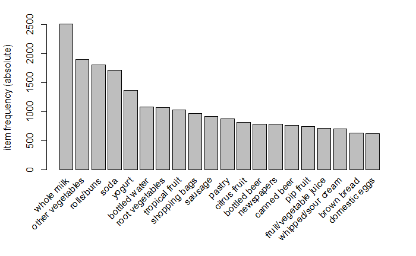

```r
itemFrequencyPlot(Groceries,topN=20,type="absolute")
```

```r
groceryRules <- apriori(Groceries,parameter = list(support=0.001, confidence=0.8))
```

```
Apriori

Parameter specification:
 confidence minval smax arem  aval originalSupport maxtime support minlen maxlen target   ext
        0.8    0.1    1 none FALSE            TRUE       5   0.001      1     10  rules FALSE

Algorithmic control:
 filter tree heap memopt load sort verbose
    0.1 TRUE TRUE  FALSE TRUE    2    TRUE

Absolute minimum support count: 9

set item appearances ...[0 item(s)] done [0.00s].
set transactions ...[169 item(s), 9835 transaction(s)] done [0.01s].
sorting and recoding items ... [157 item(s)] done [0.00s].
creating transaction tree ... done [0.00s].
checking subsets of size 1 2 3 4 5 6 done [0.02s].
writing ... [410 rule(s)] done [0.00s].
creating S4 object  ... done [0.00s].
```

```r
options(digits = 2)
inspect(groceryRules[1:5])
```

```
    lhs                        rhs            support confidence lift count
[1] {liquor,red/blush wine} => {bottled beer} 0.0019  0.90       11.2 19
[2] {curd,cereals}          => {whole milk}   0.0010  0.91        3.6 10
[3] {yogurt,cereals}        => {whole milk}   0.0017  0.81        3.2 17
[4] {butter,jam}            => {whole milk}   0.0010  0.83        3.3 10
[5] {soups,bottled beer}    => {whole milk}   0.0011  0.92        3.6 11
```

```r
rul <- sort(groceryRules, by="confidence", decreasinig=TRUE)
```

Targeting Items

```r
groceryRules <- apriori(Groceries,parameter = list(support=0.001, confidence=0.03),
                        appearance = list(default="lhs",rhs='soda'))
```

```
Apriori

Parameter specification:
 confidence minval smax arem  aval originalSupport maxtime support minlen maxlen target   ext
       0.03    0.1    1 none FALSE            TRUE       5   0.001      1     10  rules FALSE

Algorithmic control:
 filter tree heap memopt load sort verbose
    0.1 TRUE TRUE  FALSE TRUE    2    TRUE

Absolute minimum support count: 9

set item appearances ...[1 item(s)] done [0.00s].
set transactions ...[169 item(s), 9835 transaction(s)] done [0.00s].
sorting and recoding items ... [157 item(s)] done [0.00s].
creating transaction tree ... done [0.00s].
checking subsets of size 1 2 3 4 5 6 done [0.04s].
writing ... [1366 rule(s)] done [0.00s].
creating S4 object  ... done [0.00s].
```

```r
rul <- sort(groceryRules, by="confidence", decreasinig=TRUE)
inspect(rul[1:5])
```

```
    lhs                                             rhs    support confidence lift count
[1] {coffee,misc. beverages}                     => {soda} 0.0010  0.77       4.4  10
[2] {yogurt,rolls/buns,bottled water,newspapers} => {soda} 0.0010  0.77       4.4  10
[3] {sausage,bottled water,bottled beer}         => {soda} 0.0011  0.73       4.2  11
[4] {sausage,white bread,shopping bags}          => {soda} 0.0010  0.67       3.8  10
[5] {rolls/buns,bottled water,chocolate}         => {soda} 0.0013  0.65       3.7  13
```

#### Matrix Factorization

In otehr words called as Decomposition. Dimensionality Reduction. THe reason we need DR is that ther are sparse data when it comes to recommendation system. Inorder to reduce the size and dimension we use DR.

Most commonly used DR algorithm is Singular Value Decomposition

```r
svdM <- svd(movie.m)
sigmaK <- svdM$d; Uk <- svdM$u; Vk <- svdM$v
```

```r
plot(sigmaK,pch=20, main="Singular value for User-Item Matrix")
```

[output not shown]

```r
sigmaK[1:100]
```

[output not shown]

```r
all_sq <- sum(sigmaK^2)
```

```r
vecc <- NULL

for(i in 1:length(sigmaK)){
  vecc[i] <- sum(sigmaK[1:i]^2) / all_sq
}
```

```r
plot(vecc, col="red")
lines(x=c(0,1000),y=c(.90,.90))
```

[output not shown]

```r
length(vecc[vecc <= .90])
```

[output not shown]

```r
# when k=286, we create a truncated svd

sigmaK2 <- Diagonal(x=sigmaK[1:286])
dim(sigmaK2)
Uk2 <- Uk[,1:286]
dim(Uk2)
Vk2 <- t(Vk[,1:286])
dim(Vk2)
```

```r
# Actual dimensions
1664*943
```

```
[1] 1569152
```

```r
#SVD dimensions
(943*286)+(286*286)+(286*1664)
```

```
[1] 827398
```

```r
827398/1569152
```

```
[1] 0.5272899
```

```r
predicted <- Uk2 %*% sigmaK2 %*% Vk2
```

#### Using RecommenderLab

Finding Similar User

```r
similarity_users <- similarity(MovieLense[1:4, ], method = "cosine", which = "users")

image(as.matrix(similarity_users), main = "User similarity")
```

[output not shown]

Finding Similar Item

```r
similarity_items <- similarity(MovieLense[, 1:4], method = "cosine", which = "items")

image(as.matrix(similarity_items), main = "Item similarity")
```

[output not shown]

DIfferent Models available in Recommnederlab

```r
recommender_models <- recommenderRegistry$get_entries(dataType = "realRatingMatrix")
recommender_models
```

```
$ALS_realRatingMatrix
Recommender method: ALS for realRatingMatrix
Description: Recommender for explicit ratings based on latent factors, calculated by alternating least squares algorithm.
Reference: Yunhong Zhou, Dennis Wilkinson, Robert Schreiber, Rong Pan (2008). Large-Scale Parallel Collaborative Filtering for the Netflix Prize, 4th Int'l Conf. Algorithmic Aspects in Information and Management, LNCS 5034.
Parameters:
  normalize lambda n_factors n_iterations min_item_nr seed
1      NULL    0.1        10           10           1 NULL

$ALS_implicit_realRatingMatrix
Recommender method: ALS_implicit for realRatingMatrix
Description: Recommender for implicit data based on latent factors, calculated by alternating least squares algorithm.
Reference: Yifan Hu, Yehuda Koren, Chris Volinsky (2008). Collaborative Filtering for Implicit Feedback Datasets, ICDM '08 Proceedings of the 2008 Eighth IEEE International Conference on Data Mining, pages 263-272.
Parameters:
  lambda alpha n_factors n_iterations min_item_nr seed
1    0.1    10        10           10           1 NULL

$IBCF_realRatingMatrix
Recommender method: IBCF for realRatingMatrix
Description: Recommender based on item-based collaborative filtering.
Reference: NA
Parameters:
   k   method normalize normalize_sim_matrix alpha na_as_zero
1 30 "Cosine"  "center"                FALSE   0.5      FALSE

$POPULAR_realRatingMatrix
Recommender method: POPULAR for realRatingMatrix
Description: Recommender based on item popularity.
Reference: NA
Parameters:
  normalize    aggregationRatings aggregationPopularity
1  "center" new("standardGeneric" new("standardGeneric"

$RANDOM_realRatingMatrix
Recommender method: RANDOM for realRatingMatrix
Description: Produce random recommendations (real ratings).
Reference: NA
Parameters: None

$RERECOMMEND_realRatingMatrix
Recommender method: RERECOMMEND for realRatingMatrix
```

[output cut: 14 more lines]

```
$SVDF_realRatingMatrix
Recommender method: SVDF for realRatingMatrix
Description: Recommender based on Funk SVD with gradient descend.
Reference: NA
Parameters:
   k gamma lambda min_epochs max_epochs min_improvement normalize verbose
1 10 0.015  0.001         50        200           1e-06  "center"   FALSE

$UBCF_realRatingMatrix
Recommender method: UBCF for realRatingMatrix
Description: Recommender based on user-based collaborative filtering.
Reference: NA
Parameters:
    method nn sample normalize
1 "cosine" 25  FALSE  "center"
```

Geting only the most relavent user and movies

```r
ratings_movies <- MovieLense[rowCounts(MovieLense) > 50,
                             colCounts(MovieLense) > 100]
ratings_movies_watched <- binarize(ratings_movies, minRating = 1)
```

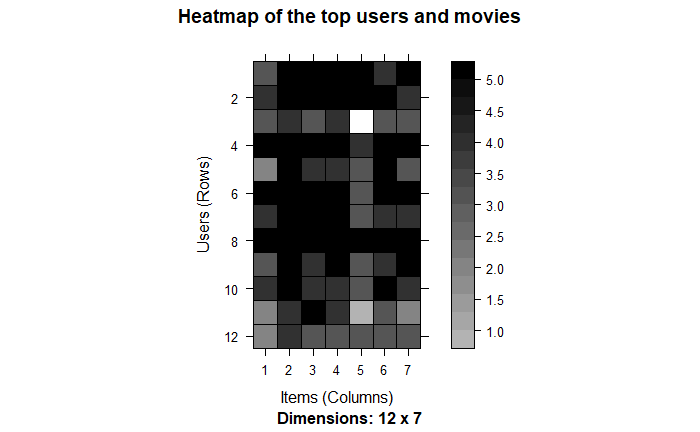

```r
# visualize the top matrix
min_movies <- quantile(rowCounts(ratings_movies), 0.98)
min_users <- quantile(colCounts(ratings_movies), 0.98)
image(ratings_movies[rowCounts(ratings_movies) > min_movies,
                     colCounts(ratings_movies) > min_users],
      main = "Heatmap of the top users and movies")
```

Normalizing the Dataset

```r
ratings_movies_norm <- normalize(ratings_movies)
```

Creating a Train/Test Dataset

```r
which_train <- sample(x = c(TRUE, FALSE),
                      size = nrow(ratings_movies),
                      replace = TRUE,
                      prob = c(0.8, 0.2))
recc_data_train <- ratings_movies[which_train, ]
recc_data_test <- ratings_movies[!which_train, ]
```

Item based CF

```r
recc_model <- Recommender(data = recc_data_train,
                          method = "IBCF",
                          parameter = list(method = "Jaccard"))
model_details <- getModel(recc_model)
```

```r
n_recommended <- 6
recc_predicted <- predict(object = recc_model,
                          newdata = recc_data_test,
                          n = n_recommended)
recc_matrix <- sapply(recc_predicted@items, function(x){
  colnames(ratings_movies)[x]
})
```

User Based CF

```r
recc_model <- Recommender(data = recc_data_train,
                          method = "UBCF",
                          parameter = list(method = "Jaccard"))
recc_model
```

```
Recommender of type UBCF for realRatingMatrix
learned using 451 users.
```

```r
n_recommended <- 15
recc_predicted <- predict(object = recc_model,
                          newdata = recc_data_test,
                          n = n_recommended)
recc_matrix <- sapply(recc_predicted@items, function(x){
  colnames(ratings_movies)[x]
})
dim(recc_matrix)
```

```
[1]  15 109
```

```r
recc_matrix[,1:2]
```

```
      10                                    25
 [1,] "Return of the Jedi (1983)"           "Fargo (1996)"
 [2,] "Princess Bride, The (1987)"          "Dead Man Walking (1995)"
 [3,] "Schindler's List (1993)"             "Pulp Fiction (1994)"
 [4,] "Close Shave, A (1995)"               "Schindler's List (1993)"
 [5,] "Young Frankenstein (1974)"           "Shawshank Redemption, The (1994)"
 [6,] "Mr. Holland's Opus (1995)"           "Mr. Holland's Opus (1995)"
 [7,] "Empire Strikes Back, The (1980)"     "Empire Strikes Back, The (1980)"
 [8,] "To Kill a Mockingbird (1962)"        "Usual Suspects, The (1995)"
 [9,] "Star Trek: The Wrath of Khan (1982)" "L.A. Confidential (1997)"
[10,] "Contact (1997)"                      "Sling Blade (1996)"
[11,] "Back to the Future (1985)"           "Lone Star (1996)"
[12,] "Terminator 2: Judgment Day (1991)"   "Sting, The (1973)"
[13,] "Wrong Trousers, The (1993)"          "Big Night (1996)"
[14,] "This Is Spinal Tap (1984)"           "Lawrence of Arabia (1962)"
[15,] "Blade Runner (1982)"                 "Secrets & Lies (1996)"
```

```r
user_movies <- movie.m[10,]
viewed_movies <- colnames(user_movies[,user_movies==1])
#viewed_movies
cat('\n Movies to recommend \n \n')
```

```
 Movies to recommend
```

```r
listing <- most.prob.movies(10,movie.m,distance)
colnames(movie.m)[listing[1:10]]
```

```
 [1] "Schindler's List (1993)"         "Annie Hall (1977)"               "Godfather: Part II, The (1974)"
 [4] "Cool Hand Luke (1967)"           "Blade Runner (1982)"             "To Kill a Mockingbird (1962)"
 [7] "Fugitive, The (1993)"            "Empire Strikes Back, The (1980)" "Back to the Future (1985)"
[10] "Much Ado About Nothing (1993)"
```

```r
recc_model <- Recommender(data = recc_data_train,
                          method = "SVD",
                          parameter = list(method = "Jaccard"))
recc_model
```

```r
n_fold <- 4
items_to_keep <- 15
rating_threshold <- 3
eval_sets <- evaluationScheme(data = ratings_movies, method = "split", train=0.8,
k = n_fold, given = items_to_keep, goodRating = rating_threshold)
```

```r
UBCF_N_C <- Recommender(getData(eval_sets, "train"), "UBCF",
      param=list(normalize = NULL, method="Cosine"))
# centered
IBCF_Z_C <- Recommender(getData(eval_sets, "train"), "IBCF",
      param=list(normalize = "Z-score",method="Cosine"))
```

```r
Jp1 <- predict(UBCF_N_C, getData(eval_sets, "known"), type="ratings")
Jp2 <- predict(IBCF_Z_C, getData(eval_sets, "known"), type="ratings")
```

```r
errors <- rbind(
  # jester data
  UBCF_N_C = calcPredictionAccuracy(Jp1, getData(eval_sets, "unknown")),
  IBCF_Z_C = calcPredictionAccuracy(Jp2, getData(eval_sets, "unknown"))
)
```

```r
errors
```

```
         RMSE  MSE MAE
UBCF_N_C  3.3 10.8 3.1
IBCF_Z_C  1.4  1.9 1.1
```